# Proyecto colocaciones - Diana Bayona (1) (1)

### Universidad Santo Tomás

#### Visualización ciencia de datos en python

##### Participantes:

- **Diana Liceth Bayona Patiño**
- **Jhon Sebastian Castro Reyes**
- **Yulian Alejandra Rozo Moscoso**

### Limpieza de los datos

```python
import pandas as pd
import numpy as np
import seaborn as sns
import matplotlib as plt
import matplotlib.pyplot as plt

pd.set_option('display.max_columns', None) #Mostrar todas las columnas
```

```python
df_colocaciones = pd.read_csv('C:/Users/july3/Downloads/Colocaciones_de_cr_dito_Sector_Agropecuario_2020.csv',
                 sep = ',', thousands=',', decimal='.')
```

Se referencia los [Datos abiertos Colocaciones de crédito Sector Agropecuario 2020](https://www.datos.gov.co/Agricultura-y-Desarrollo-Rural/Colocaciones-de-cr-dito-Sector-Agropecuario-2020/hbaj-th4x/data) adicionalmente podemos encontrar la tabla de contenido, del significado de cada variable

```python
df_colocaciones.head()
```

|  | Año | Mes | fuente Colocacion | Id Tipo Prod | Tipo Productor | Valor Inversion | Colocacion | ID Depto | Departamento Inversion | Id Munic | Municipio Inversion | Municipio de PostConflico? | DEPCOL | Departamento de Colocacion de Credito | MUNCOL | Municipio Colocacion de Credito | Plazo | Linea de Credito | Linea de Produccion | ID Rubro | Destino de Credito | Genero | % FAG | Vlr Inic Garantia | LATITUD | LONGITUD | CANTIDAD | Coordenada |
| --- | --- | --- | --- | --- | --- | --- | --- | --- | --- | --- | --- | --- | --- | --- | --- | --- | --- | --- | --- | --- | --- | --- | --- | --- | --- | --- | --- | --- |
| 0 | 2020 | 1 | REDESCUENTO | 0 | PEQUEÑO | 5500000.0 | 5500000.0 | 52 | NARIÑO | 52694 | SAN PEDRO DE CARTAGO | N | 52 | NARIÑO | 52399 | LA UNION | 60 | Inversión | MAQUINARIA Y EQUIPO (I) | 447600 | MAQUINARIA USADA | HOMBRE | 80.0 | 4400000.0 | 1.561389 | -77.118056 | 1 | POINT (-77.1180556 1.5613889) |
| 1 | 2020 | 1 | REDESCUENTO | 0 | PEQUEÑO | 21000000.0 | 21000000.0 | 23 | CORDOBA | 23500 | MONITOS | N | 23 | CORDOBA | 23500 | MONITOS | 72 | Inversión | SIEMBRAS (I) | 141430 | PLATANO - INVERSIÓN | MUJER | 80.0 | 16800000.0 | 8.250000 | -76.050000 | 1 | POINT (-76.05 8.25) |
| 2 | 2020 | 1 | REDESCUENTO | 0 | PEQUEÑO | 6000000.0 | 4130000.0 | 15 | BOYACA | 15176 | CHIQUINQUIRA | N | 15 | BOYACA | 15176 | CHIQUINQUIRA | 24 | Capital de Trabajo | SOSTENIMIENTO (CT) | 160000 | CAPITAL DE TRABAJO UNIDAD PROD CAMPESINA | HOMBRE | 80.0 | 3304000.0 | 5.633333 | -73.750000 | 1 | POINT (-73.75 5.6333333) |
| 3 | 2020 | 1 | REDESCUENTO | 0 | PEQUEÑO | 9000000.0 | 6000000.0 | 25 | CUNDINAMARCA | 25377 | LA CALERA | N | 25 | CUNDINAMARCA | 25377 | LA CALERA | 24 | Capital de Trabajo | SOSTENIMIENTO (CT) | 237280 | CEBA BOVINA - SOSTENIMIENTO | MUJER | 80.0 | 4800000.0 | 4.750000 | -73.916667 | 1 | POINT (-73.9166667 4.75) |
| 4 | 2020 | 1 | REDESCUENTO | 0 | PEQUEÑO | 4000000.0 | 4000000.0 | 50 | META | 50573 | PUERTO LOPEZ | N | 50 | META | 50573 | PUERTO LOPEZ | 60 | Inversión | MAQUINARIA Y EQUIPO (I) | 447350 | EQUIPOS PARA ACUICULTURA Y PESCA | HOMBRE | 80.0 | 3200000.0 | 4.083333 | -72.966667 | 1 | POINT (-72.9666667 4.0833333) |

Dimensión de los datos

```python
print('CONTEO')
print('Filas: ', df_colocaciones.shape[0])
print('Columnas: ', df_colocaciones.shape[1])
```

```
CONTEO
Filas:  513235
Columnas:  28
```

Atributos y tipos de atributos

```python
df_colocaciones.dtypes
```

```
Año                                        int64
Mes                                        int64
fuente Colocacion                         object
Id Tipo Prod                               int64
Tipo Productor                            object
Valor Inversion                          float64
Colocacion                               float64
ID Depto                                   int64
Departamento Inversion                    object
Id Munic                                   int64
Municipio Inversion                       object
Municipio de PostConflico?                object
DEPCOL                                     int64
Departamento de Colocacion de Credito     object
MUNCOL                                     int64
Municipio Colocacion de Credito           object
Plazo                                      int64
Linea de Credito                          object
Linea de Produccion                       object
ID Rubro                                   int64
Destino de Credito                        object
Genero                                    object
% FAG                                    float64
Vlr Inic Garantia                        float64
LATITUD                                  float64
LONGITUD                                 float64
CANTIDAD                                   int64
Coordenada                                object
dtype: object
```

### Completitud

Valores faltantes

```python
for col in df_colocaciones.columns:
    num_missing = df_colocaciones[col].isnull().sum()
    pct_missing = np.mean(df_colocaciones[col].isnull())
    #print(col," - ",round(pct_missing*100, 2),"% - ",num_missing)
    print('{} - {}% - {}'.format(col,round(pct_missing*100, 2),num_missing))
```

```
Año - 0.0% - 0
Mes - 0.0% - 0
fuente Colocacion - 0.0% - 0
Id Tipo Prod - 0.0% - 0
Tipo Productor - 0.0% - 0
Valor Inversion - 0.0% - 0
Colocacion - 0.0% - 0
ID Depto - 0.0% - 0
Departamento Inversion - 0.0% - 0
Id Munic - 0.0% - 0
Municipio Inversion - 0.0% - 0
Municipio de PostConflico? - 0.0% - 0
DEPCOL - 0.0% - 0
Departamento de Colocacion de Credito - 0.0% - 0
MUNCOL - 0.0% - 0
Municipio Colocacion de Credito - 0.0% - 0
Plazo - 0.0% - 0
Linea de Credito - 0.0% - 0
Linea de Produccion - 0.0% - 0
ID Rubro - 0.0% - 0
Destino de Credito - 0.0% - 0
Genero - 0.0% - 0
% FAG - 46.07% - 236472
Vlr Inic Garantia - 46.07% - 236472
LATITUD - 0.0% - 0
LONGITUD - 0.0% - 0
CANTIDAD - 0.0% - 0
Coordenada - 0.0% - 0
```

Las variables % FAG y Vlr Inic Garantia tienen un porcentaje de 46.07% de datos faltantes, esta variable representa el Fondo Agropecuario de Garantias la cual indica el valor del fondo con el que se busca respaldar los créditos concedidos por Finagro. Se decide eliminar estas variables debido a que son cuantitativas y no se puede clasificar en la categoría "pérdido", así mismo su alto porcentaje de datos faltantes hace que la imputación no sea una vía adecuada.

### Seleccionar columnas sin variables %FAG y Vlr Garantia

```python
columns = ["Año",
           "Mes",
           "fuente Colocacion",
           "Id Tipo Prod" ,
           "Tipo Productor" ,
           "Valor Inversion",
           "Colocacion" ,
           "ID Depto" ,
           "Departamento Inversion",
           "Id Munic" ,
           "Municipio Inversion",
           "Municipio de PostConflico?" ,
           "DEPCOL",
           "Departamento de Colocacion de Credito",
           "MUNCOL",
           "Municipio Colocacion de Credito",
           "Plazo",
           "Linea de Credito" ,
           "Linea de Produccion",
           "ID Rubro",
           "Destino de Credito" ,
           "Genero",
           "LATITUD",
           "LONGITUD",
           "CANTIDAD",
           "Coordenada"
          ]
df = df_colocaciones.copy()
df = df_colocaciones[columns]
df
```

|  | Año | Mes | fuente Colocacion | Id Tipo Prod | Tipo Productor | Valor Inversion | Colocacion | ID Depto | Departamento Inversion | Id Munic | Municipio Inversion | Municipio de PostConflico? | DEPCOL | Departamento de Colocacion de Credito | MUNCOL | Municipio Colocacion de Credito | Plazo | Linea de Credito | Linea de Produccion | ID Rubro | Destino de Credito | Genero | LATITUD | LONGITUD | CANTIDAD | Coordenada |
| --- | --- | --- | --- | --- | --- | --- | --- | --- | --- | --- | --- | --- | --- | --- | --- | --- | --- | --- | --- | --- | --- | --- | --- | --- | --- | --- |
| 0 | 2020 | 1 | REDESCUENTO | 0 | PEQUEÑO | 5500000.0 | 5500000.0 | 52 | NARIÑO | 52694 | SAN PEDRO DE CARTAGO | N | 52 | NARIÑO | 52399 | LA UNION | 60 | Inversión | MAQUINARIA Y EQUIPO (I) | 447600 | MAQUINARIA USADA | HOMBRE | 1.561389 | -77.118056 | 1 | POINT (-77.1180556 1.5613889) |
| 1 | 2020 | 1 | REDESCUENTO | 0 | PEQUEÑO | 21000000.0 | 21000000.0 | 23 | CORDOBA | 23500 | MONITOS | N | 23 | CORDOBA | 23500 | MONITOS | 72 | Inversión | SIEMBRAS (I) | 141430 | PLATANO - INVERSIÓN | MUJER | 8.250000 | -76.050000 | 1 | POINT (-76.05 8.25) |
| 2 | 2020 | 1 | REDESCUENTO | 0 | PEQUEÑO | 6000000.0 | 4130000.0 | 15 | BOYACA | 15176 | CHIQUINQUIRA | N | 15 | BOYACA | 15176 | CHIQUINQUIRA | 24 | Capital de Trabajo | SOSTENIMIENTO (CT) | 160000 | CAPITAL DE TRABAJO UNIDAD PROD CAMPESINA | HOMBRE | 5.633333 | -73.750000 | 1 | POINT (-73.75 5.6333333) |
| 3 | 2020 | 1 | REDESCUENTO | 0 | PEQUEÑO | 9000000.0 | 6000000.0 | 25 | CUNDINAMARCA | 25377 | LA CALERA | N | 25 | CUNDINAMARCA | 25377 | LA CALERA | 24 | Capital de Trabajo | SOSTENIMIENTO (CT) | 237280 | CEBA BOVINA - SOSTENIMIENTO | MUJER | 4.750000 | -73.916667 | 1 | POINT (-73.9166667 4.75) |
| 4 | 2020 | 1 | REDESCUENTO | 0 | PEQUEÑO | 4000000.0 | 4000000.0 | 50 | META | 50573 | PUERTO LOPEZ | N | 50 | META | 50573 | PUERTO LOPEZ | 60 | Inversión | MAQUINARIA Y EQUIPO (I) | 447350 | EQUIPOS PARA ACUICULTURA Y PESCA | HOMBRE | 4.083333 | -72.966667 | 1 | POINT (-72.9666667 4.0833333) |
| ... | ... | ... | ... | ... | ... | ... | ... | ... | ... | ... | ... | ... | ... | ... | ... | ... | ... | ... | ... | ... | ... | ... | ... | ... | ... | ... |
| 513230 | 2020 | 11 | REDESCUENTO | 0 | PEQUEÑO | 8000000.0 | 8000000.0 | 52 | NARIÑO | 52001 | PASTO | N | 52 | NARIÑO | 52001 | PASTO | 36 | Capital de Trabajo | SOSTENIMIENTO (CT) | 160000 | 160000 CAPITAL DE TRABAJO - UNIDAD PRODUCTIVA ... | M | 1.214671 | -77.278647 | 1 | POINT (-77.27864742 1.214670737) |
| 513231 | 2020 | 11 | REDESCUENTO | 0 | PEQUEÑO | 10000000.0 | 10000000.0 | 41 | HUILA | 41359 | ISNOS | N | 41 | HUILA | 41359 | ISNOS | 36 | Capital de Trabajo | SOSTENIMIENTO (CT) | 160000 | 160000 CAPITAL DE TRABAJO - UNIDAD PRODUCTIVA ... | M | 2.083333 | -76.250000 | 1 | POINT (-76.25 2.0833333) |
| 513232 | 2020 | 11 | REDESCUENTO | 0 | PEQUEÑO | 2000000.0 | 2000000.0 | 17 | CALDAS | 17042 | ANSERMA | N | 17 | CALDAS | 17042 | ANSERMA | 13 | Capital de Trabajo | SOSTENIMIENTO (CT) | 160000 | 160000 CAPITAL DE TRABAJO - UNIDAD PRODUCTIVA ... | M | 5.250000 | -75.750000 | 1 | POINT (-75.75 5.25) |
| 513233 | 2020 | 11 | REDESCUENTO | 0 | PEQUEÑO | 7200000.0 | 7200000.0 | 25 | CUNDINAMARCA | 25885 | YACOPI | N | 25 | CUNDINAMARCA | 25885 | YACOPI | 36 | Capital de Trabajo | SOSTENIMIENTO (CT) | 160000 | 160000 CAPITAL DE TRABAJO - UNIDAD PRODUCTIVA ... | M | 5.666667 | -74.416667 | 1 | POINT (-74.4166667 5.6666667) |
| 513234 | 2020 | 11 | REDESCUENTO | 0 | PEQUEÑO | 8000000.0 | 8000000.0 | 17 | CALDAS | 17665 | SAN JOSE | N | 17 | CALDAS | 17665 | SAN JOSE | 36 | Capital de Trabajo | SOSTENIMIENTO (CT) | 160000 | 160000 CAPITAL DE TRABAJO - UNIDAD PRODUCTIVA ... | M | 5.085833 | -75.788333 | 1 | POINT (-75.7883333 5.0858333) |

513235 rows × 26 columns

```python
print('CONTEO')
print('Filas: ', df.shape[0])
print('Columnas: ', df.shape[1])
```

```
CONTEO
Filas:  513235
Columnas:  26
```

### Coherencia

#### Datos duplicados

```python
df[df.duplicated()]
```

|  | Año | Mes | fuente Colocacion | Id Tipo Prod | Tipo Productor | Valor Inversion | Colocacion | ID Depto | Departamento Inversion | Id Munic | Municipio Inversion | Municipio de PostConflico? | DEPCOL | Departamento de Colocacion de Credito | MUNCOL | Municipio Colocacion de Credito | Plazo | Linea de Credito | Linea de Produccion | ID Rubro | Destino de Credito | Genero | LATITUD | LONGITUD | CANTIDAD | Coordenada |
| --- | --- | --- | --- | --- | --- | --- | --- | --- | --- | --- | --- | --- | --- | --- | --- | --- | --- | --- | --- | --- | --- | --- | --- | --- | --- | --- |
| 411 | 2020 | 1 | REDESCUENTO | 0 | PEQUEÑO | 10000000.0 | 10000000.0 | 25 | CUNDINAMARCA | 25148 | CAPARRAPI | N | 25 | CUNDINAMARCA | 25148 | CAPARRAPI | 24 | Capital de Trabajo | SOSTENIMIENTO (CT) | 237280 | CEBA BOVINA - SOSTENIMIENTO | MUJER | 5.416667 | -74.583333 | 1 | POINT (-74.5833333 5.4166667) |
| 447 | 2020 | 1 | REDESCUENTO | 0 | PEQUEÑO | 30000000.0 | 30000000.0 | 25 | CUNDINAMARCA | 25535 | PASCA | N | 25 | CUNDINAMARCA | 25535 | PASCA | 8 | Capital de Trabajo | PRODUCCIÓN (CT) | 111500 | PAPA | HOMBRE | 4.333333 | -74.283333 | 1 | POINT (-74.2833333 4.3333333) |
| 582 | 2020 | 1 | REDESCUENTO | 0 | PEQUEÑO | 15000000.0 | 12000000.0 | 15 | BOYACA | 15842 | UMBITA | N | 15 | BOYACA | 15842 | UMBITA | 60 | Inversión | COMPRA DE ANIMALES (I) | 253400 | VIENTRES BOVINOS CRIA Y DOBLE PROPOSITO | MUJER | 5.233333 | -73.450000 | 1 | POINT (-73.45 5.2333333) |
| 739 | 2020 | 1 | REDESCUENTO | 0 | PEQUEÑO | 13000000.0 | 13000000.0 | 25 | CUNDINAMARCA | 25407 | LENGUAZAQUE | N | 25 | CUNDINAMARCA | 25407 | LENGUAZAQUE | 60 | Inversión | COMPRA DE ANIMALES (I) | 253100 | VIENTRES COMERCIALES BOVINOS LECHE | HOMBRE | 5.333333 | -73.666667 | 1 | POINT (-73.6666667 5.3333333) |
| 1002 | 2020 | 1 | REDESCUENTO | 0 | PEQUEÑO | 8000000.0 | 8000000.0 | 25 | CUNDINAMARCA | 25535 | PASCA | N | 25 | CUNDINAMARCA | 25535 | PASCA | 60 | Inversión | SIEMBRAS (I) | 151380 | MORA | MUJER | 4.333333 | -74.283333 | 1 | POINT (-74.2833333 4.3333333) |
| ... | ... | ... | ... | ... | ... | ... | ... | ... | ... | ... | ... | ... | ... | ... | ... | ... | ... | ... | ... | ... | ... | ... | ... | ... | ... | ... |
| 513217 | 2020 | 11 | REDESCUENTO | 0 | PEQUEÑO | 6000000.0 | 6000000.0 | 73 | TOLIMA | 73283 | FRESNO | N | 73 | TOLIMA | 73283 | FRESNO | 36 | Capital de Trabajo | SOSTENIMIENTO (CT) | 160000 | 160000 CAPITAL DE TRABAJO - UNIDAD PRODUCTIVA ... | M | 5.166667 | -75.083333 | 1 | POINT (-75.0833333 5.1666667) |
| 513219 | 2020 | 11 | REDESCUENTO | 0 | PEQUEÑO | 7000000.0 | 7000000.0 | 52 | NARIÑO | 52036 | ANCUYA | N | 52 | NARIÑO | 52480 | NARIÑO | 36 | Capital de Trabajo | SOSTENIMIENTO (CT) | 160000 | 160000 CAPITAL DE TRABAJO - UNIDAD PRODUCTIVA ... | M | 1.250000 | -77.500000 | 1 | POINT (-77.5 1.25) |
| 513221 | 2020 | 11 | REDESCUENTO | 0 | PEQUEÑO | 8700000.0 | 8700000.0 | 73 | TOLIMA | 73555 | PLANADAS | S | 73 | TOLIMA | 73555 | PLANADAS | 36 | Capital de Trabajo | SOSTENIMIENTO (CT) | 160000 | 160000 CAPITAL DE TRABAJO - UNIDAD PRODUCTIVA ... | H | 3.250000 | -75.750000 | 1 | POINT (-75.75 3.25) |
| 513225 | 2020 | 11 | REDESCUENTO | 0 | PEQUEÑO | 7000000.0 | 7000000.0 | 17 | CALDAS | 17614 | RIOSUCIO | N | 17 | CALDAS | 17614 | RIOSUCIO | 36 | Capital de Trabajo | SOSTENIMIENTO (CT) | 160000 | 160000 CAPITAL DE TRABAJO - UNIDAD PRODUCTIVA ... | H | 5.379167 | -75.616111 | 1 | POINT (-75.6161111 5.3791667) |
| 513230 | 2020 | 11 | REDESCUENTO | 0 | PEQUEÑO | 8000000.0 | 8000000.0 | 52 | NARIÑO | 52001 | PASTO | N | 52 | NARIÑO | 52001 | PASTO | 36 | Capital de Trabajo | SOSTENIMIENTO (CT) | 160000 | 160000 CAPITAL DE TRABAJO - UNIDAD PRODUCTIVA ... | M | 1.214671 | -77.278647 | 1 | POINT (-77.27864742 1.214670737) |

24769 rows × 26 columns

Como se puede evidenciar la base original tiene 24769 datos duplicados

```python
df_dedupped = df.drop_duplicates()
print(df.shape)
print(df_dedupped.shape)
```

```
(513235, 26)
(488466, 26)
```

### Consistencia

```python
df_dedupped.dtypes
```

```
Año                                        int64
Mes                                        int64
fuente Colocacion                         object
Id Tipo Prod                               int64
Tipo Productor                            object
Valor Inversion                          float64
Colocacion                               float64
ID Depto                                   int64
Departamento Inversion                    object
Id Munic                                   int64
Municipio Inversion                       object
Municipio de PostConflico?                object
DEPCOL                                     int64
Departamento de Colocacion de Credito     object
MUNCOL                                     int64
Municipio Colocacion de Credito           object
Plazo                                      int64
Linea de Credito                          object
Linea de Produccion                       object
ID Rubro                                   int64
Destino de Credito                        object
Genero                                    object
LATITUD                                  float64
LONGITUD                                 float64
CANTIDAD                                   int64
Coordenada                                object
dtype: object
```

```python
df_dedupped['Año'].value_counts()
```

```
2020    488466
Name: Año, dtype: int64
```

```python
df_dedupped['Mes'].value_counts()
```

```
9     92253
10    83944
8     42462
7     37180
2     33304
12    32704
1     32427
3     31238
11    31159
6     28756
4     22333
5     20706
Name: Mes, dtype: int64
```

```python
pd.set_option('display.float_format', lambda x: '%.3f' % x)
df_dedupped['Colocacion'].describe()
```

```
count         488466.000
mean        48545734.076
std        940029676.023
min                9.000
25%          3200000.000
50%          7000000.000
75%         13000000.000
max     200000000000.000
Name: Colocacion, dtype: float64
```

```python
pd.set_option('display.float_format', lambda x: '%.3f' % x)
df_dedupped['Valor Inversion'].describe()
```

```
count          488466.000
mean         89658543.483
std        8268298418.124
min                 0.000
25%           4000000.000
50%           9000000.000
75%          15000000.000
max     3272000000000.000
Name: Valor Inversion, dtype: float64
```

Exportar los datos

```python
df_dedupped.to_csv("Datos_colocaciones.csv")
```

```python
df_dedupped['Tipo Productor'].value_counts()
```

```
PEQUEÑO    417897
MEDIANO     59208
GRANDE      11361
Name: Tipo Productor, dtype: int64
```

```python
df_dedupped['Linea de Produccion'].value_counts()
```

```
SOSTENIMIENTO (CT)                 123693
SIEMBRAS (I)                       111484
COMPRA DE ANIMALES (I)             108310
MICROCREDITO (CT)                   54241
PRODUCCIÓN (CT)                     27872
INFRAEST Y ADECU DE TIERRAS (I)     24200
COMERCIALIZACION (CT)               10476
OTRAS ACTIVIDADES (I)                6605
MAQUINARIA Y EQUIPO (I)              6375
COMERCIALIZACION (I)                 5310
SERVICIOS DE APOYO (CT)              5120
CONSOLIDACION DE PASIVOS (N)         1857
ACTIVIDADES RURALES (CT)             1604
SERVICIOS DE APOYO (I)                584
ACTIVIDADES RURALES (I)               533
SERVICIOS DE APOYO  (I)               202
Name: Linea de Produccion, dtype: int64
```

### Modismo estático

```python
columns = ["Tipo Productor" ,
           "Colocacion" ,
           "Linea de Produccion"
          ]
df = df_dedupped.copy()
df = df_dedupped[columns]
df
```

|  | Tipo Productor | Colocacion | Linea de Produccion |
| --- | --- | --- | --- |
| 0 | PEQUEÑO | 5500000.000 | MAQUINARIA Y EQUIPO (I) |
| 1 | PEQUEÑO | 21000000.000 | SIEMBRAS (I) |
| 2 | PEQUEÑO | 4130000.000 | SOSTENIMIENTO (CT) |
| 3 | PEQUEÑO | 6000000.000 | SOSTENIMIENTO (CT) |
| 4 | PEQUEÑO | 4000000.000 | MAQUINARIA Y EQUIPO (I) |
| ... | ... | ... | ... |
| 513229 | PEQUEÑO | 17500000.000 | SOSTENIMIENTO (CT) |
| 513231 | PEQUEÑO | 10000000.000 | SOSTENIMIENTO (CT) |
| 513232 | PEQUEÑO | 2000000.000 | SOSTENIMIENTO (CT) |
| 513233 | PEQUEÑO | 7200000.000 | SOSTENIMIENTO (CT) |
| 513234 | PEQUEÑO | 8000000.000 | SOSTENIMIENTO (CT) |

488466 rows × 3 columns

### ¿Qué?

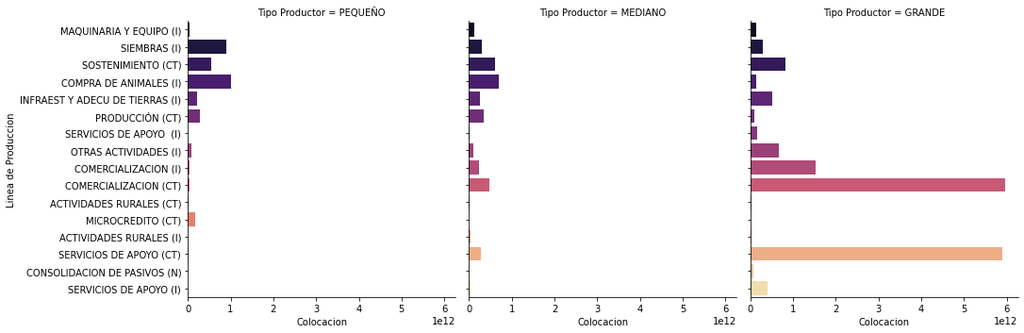

```python
sns.catplot(data = df,
            kind = "bar",
            estimator = sum,
            x = "Colocacion",
            y = "Linea de Produccion",
            col = "Tipo Productor",
            palette = 'magma',
            ci = None)
```

```python
df.groupby(['Linea de Produccion', 'Tipo Productor']).agg({"Colocacion" : ["count", "mean", "sum"]})
```

| Linea de Produccion | Tipo Productor | Colocacion count | Colocacion mean | Colocacion sum |
| --- | --- | --- | --- | --- |
| ACTIVIDADES RURALES (CT) | GRANDE | 66 | 385802358.727 | 25462955676.000 |
|  | MEDIANO | 148 | 108356520.777 | 16036765075.000 |
|  | PEQUEÑO | 1390 | 8381338.068 | 11650059914.000 |
| ACTIVIDADES RURALES (I) | GRANDE | 28 | 996949125.786 | 27914575522.000 |
|  | MEDIANO | 178 | 195719145.624 | 34838007921.000 |
|  | PEQUEÑO | 327 | 13377485.367 | 4374437715.000 |
| COMERCIALIZACION (CT) | GRANDE | 3301 | 1807349704.264 | 5966061373776.440 |
|  | MEDIANO | 4739 | 98504432.770 | 466812506895.000 |
|  | PEQUEÑO | 2436 | 19584696.658 | 47708321059.000 |
| COMERCIALIZACION (I) | GRANDE | 1652 | 922247024.563 | 1523552084578.750 |
|  | MEDIANO | 1338 | 178301953.528 | 238568013820.800 |
|  | PEQUEÑO | 2320 | 18263724.109 | 42371839934.000 |
| COMPRA DE ANIMALES (I) | GRANDE | 281 | 479478737.132 | 134733525134.000 |
|  | MEDIANO | 12279 | 56285656.594 | 691131577315.580 |
|  | PEQUEÑO | 95750 | 10553397.217 | 1010487783545.000 |
| CONSOLIDACION DE PASIVOS (N) | GRANDE | 23 | 3631516989.087 | 83524890749.000 |
|  | MEDIANO | 463 | 46794789.378 | 21665987482.000 |
|  | PEQUEÑO | 1371 | 3963761.921 | 5434317594.000 |
| INFRAEST Y ADECU DE TIERRAS (I) | GRANDE | 279 | 1836773873.190 | 512459910620.000 |
|  | MEDIANO | 3250 | 77042815.922 | 250389151745.880 |
|  | PEQUEÑO | 20671 | 10006186.493 | 206837880999.000 |
| MAQUINARIA Y EQUIPO (I) | GRANDE | 277 | 541776183.292 | 150072002772.000 |
|  | MEDIANO | 1032 | 115058075.785 | 118739934210.000 |
|  | PEQUEÑO | 5066 | 8615162.275 | 43644412085.000 |
| MICROCREDITO (CT) | MEDIANO | 132 | 6221734.341 | 821268933.000 |
|  | PEQUEÑO | 54109 | 3074158.835 | 166339660397.000 |
| OTRAS ACTIVIDADES (I) | GRANDE | 96 | 7070779507.734 | 678794832742.480 |
|  | MEDIANO | 837 | 130445958.659 | 109183267397.990 |
|  | PEQUEÑO | 5672 | 14409156.497 | 81728735650.000 |
| PRODUCCIÓN (CT) | GRANDE | 390 | 266260302.938 | 103841518146.000 |
|  | MEDIANO | 6774 | 51896309.629 | 351545601428.630 |
|  | PEQUEÑO | 20708 | 13148264.080 | 272274252567.000 |
| SERVICIOS DE APOYO (CT) | GRANDE | 2635 | 2241675292.723 | 5906814396325.910 |
|  | MEDIANO | 2153 | 129922325.494 | 279722766788.000 |
|  | PEQUEÑO | 332 | 25619623.898 | 8505715134.000 |
| SERVICIOS DE APOYO (I) | GRANDE | 303 | 1346985034.462 | 408136465442.000 |
|  | MEDIANO | 182 | 195306602.077 | 35545801578.000 |
|  | PEQUEÑO | 99 | 25455479.535 | 2520092474.000 |
| SERVICIOS DE APOYO (I) | GRANDE | 103 | 1540929710.126 | 158715760143.000 |
|  | MEDIANO | 65 | 268263186.185 | 17437107102.000 |
|  | PEQUEÑO | 34 | 36849948.706 | 1252898256.000 |
| SIEMBRAS (I) | GRANDE | 301 | 1010776246.757 | 304243650274.000 |
|  | MEDIANO | 5360 | 57155176.562 | 306351746370.000 |
|  | PEQUEÑO | 105823 | 8486452.053 | 898061815620.000 |
| SOSTENIMIENTO (CT) | GRANDE | 1626 | 511340620.234 | 831439848500.000 |
|  | MEDIANO | 20278 | 30003910.114 | 608419289293.000 |
|  | PEQUEÑO | 101789 | 5371619.077 | 546771734268.000 |

### ¿Por qué?

En en sus acciones la visualización **analiza y presenta** ya que el propósito es mostrar las colocaciones de créditos por línea de producción y tipo de productor, siendo los productores grandes los que presentan las colocaciones de créditos de mayor valor en las lineas de producción de comercialización y servicios de apoyo de capital de trabajo. Así mismo, el gráfico **consulta y compara** como acción ya que a partir de este se puede comparar los valores de colocación por línea de producción y por cada uno de los tipos de productor. Por ejemplo, para los productores pequeños las colocaciones de crédito son para líneas de producción de siembras y compras de animales, mientras que para el productor mediano los créditos son para líneas de producción de sostenimiento y compra de animales, finalmente para el productor grande las lineas de producción de comercialización y servicios de apoyo de capital de trabajo presentan las colocaciones de crédito de mayor valor.

Con respecto al objetivo, considero que este es **Tendencias** para todos los datos y con respecto a los atributos el objetivo es **distribución** dado que por medio del gráfico se pueden identificar las características de los datos y como se distribuyen estos ya que en el modismo se presentan las líneas de producción con mayor valor de colocación por tipo de productor. Igualmente, se puede evidenciar que la colocación de los créditos tiene un mayor valor para los productores grandes, mientras que para los productores pequeños y medianos no se presenta una gran diferencia en los valores de colocación.

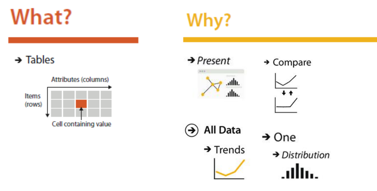

**Tarea**

La tarea y objetivo que se quiere lograr por medio de este gráfico es poder identificar las líneas de producción que tienen un mayor valor en la colocación de los créditos por tipo de productor, de esta manera Finagro quien es la entidad encargada de otorgar estas colocaciones de créditos puede ofrecer diferentes créditos según el tipo de productor y la línea de producción.

**Marcas**

La marca para este gráfico son las líneas que son representadas por medio de las barras horizontales.

**Canales**

- Canal de posición espacial vertical para el atributo categórico de las líneas de producción.
- Canal de posición espacial horizontal para el atributo cuantitativo del valor de colocación del crédito por cada una de las líneas de producción.
- Canal de Small Multiples para un segundo atributo categórico que representa el tipo de productor.

## grafico #2

```python
df_dedupped['Plazo'].value_counts()
```

```
36     65972
60     47418
12     39546
24     38001
72     23044
       ...
217        1
164        1
160        1
155        1
218        1
Name: Plazo, Length: 179, dtype: int64
```

```python
df_dedupped['Linea de Credito'].value_counts()
```

```
Capital de Trabajo          198348
Normalización de Cartera    158000
Inversión                   132118
Name: Linea de Credito, dtype: int64
```

```python
df_dedupped['fuente Colocacion'].value_counts()
```

```
REDESCUENTO     400717
SUSTITUTA        82856
AGROPECUARIA      4893
Name: fuente Colocacion, dtype: int64
```

estan son las variables que escogi para la visualizacion y analisis del que y porque.

```python
columns = ["fuente Colocacion" ,
           "Linea de Credito" ,
           "Plazo"
          ]
df1 = df_dedupped.copy()
df1 = df_dedupped[columns]
df1
```

|  | fuente Colocacion | Linea de Credito | Plazo |
| --- | --- | --- | --- |
| 0 | REDESCUENTO | Inversión | 60 |
| 1 | REDESCUENTO | Inversión | 72 |
| 2 | REDESCUENTO | Capital de Trabajo | 24 |
| 3 | REDESCUENTO | Capital de Trabajo | 24 |
| 4 | REDESCUENTO | Inversión | 60 |
| ... | ... | ... | ... |
| 513229 | REDESCUENTO | Capital de Trabajo | 36 |
| 513231 | REDESCUENTO | Capital de Trabajo | 36 |
| 513232 | REDESCUENTO | Capital de Trabajo | 13 |
| 513233 | REDESCUENTO | Capital de Trabajo | 36 |
| 513234 | REDESCUENTO | Capital de Trabajo | 36 |

488466 rows × 3 columns

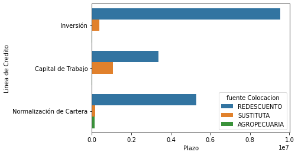

```python
sns.barplot(data = df1,
            estimator = sum,
            x = "Plazo",
            y = "Linea de Credito",
            hue = "fuente Colocacion",
            ci = None)
```

grafico de barras para los tres atributos seleccionados, podemos ver que en cada linea de credito se realizan mas Redescuentos que otros tipos de fuentes de colocacion esto podria deberse a que presuntamente los Redescuentos son para personas con empleos y las fuentes de colocacion sustitutiva son para empresarios y los agropecuarios son para personas que se dediquen a la agricultura

```python
tab1 = pd.crosstab(df1["Linea de Credito"],df_dedupped["fuente Colocacion"])
tab1
```

| fuente Colocacion Linea de Credito | AGROPECUARIA | REDESCUENTO | SUSTITUTA |
| --- | --- | --- | --- |
| Capital de Trabajo | 499 | 125585 | 72264 |
| Inversión | 88 | 125023 | 7007 |
| Normalización de Cartera | 4306 | 150109 | 3585 |

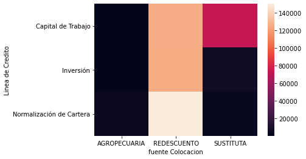

```python
ax = sns.heatmap(tab1)
```

el mapa de color nos indica como se estan comprotando nuestros datos o como se comporta la pobalcion, donde vemos que los clientes donde mas se concentra el color son el atributo de redescuento que seria la tendencia que esta siguiendo la poblacion

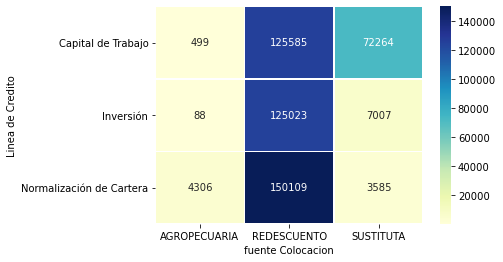

```python
ax = sns.heatmap(tab1,
                 annot=True,
                 fmt="d",
                 linewidths=.5,
                 cmap="YlGnBu")
```

el mapa de color nos indica como se estan comprotando nuestros datos o como se comporta la pobalcion, donde vemos que los clientes donde mas se concentra el color son el atributo de redescuento que seria la tendencia que esta siguiendo la poblacion

## el Porque.

recordando que es el porque en donde requerimos extraer las tareas o lo que quiere el usuario o a lo que se quiere llegar, donde se quiere analizar las variables y ubicar que tipo de credito o linea de credito es mas usada y como usan su cartera o que preferencia de cartera usan y el plazo de credito que tiene cada cliente, por el momento no usamos ninguna tranformacion en estos datos ya que se encuentran completos en cada uno de sus atributos, puede que el usuario tenga un cierto interes en saber en cuanto esta el plazo de cada cliente

## marcas.

las marcas de el grafico que use son el area o la geometria que embuelve al mapa de color, de forma cuadrada y distingue unas categorias de otras con el color de su paleta.

## canales.

los canales mas representados son el color y las marcas de linea en los diferentes graficos la pocision orizontal de grafico y las lineas del grafico de barras principalmente el de color en los 3 graficos representados y el shape tambien en el segundo mapa de color se ve un valor diferente un valor numerico que nos representa donde hay una tendencia mayor y aqui podriamos ver length.

## Grafico #3

### Modismo Estatico

Para el primer modismo se seleccionaron las variables Municipio de PostConflico?, Departamento Inversion y Valor Inversion significan lo siguiente:

1. **Municipio de PostConflico** Clasificación de los municipios si pertenecen (SI, No) a municipios de postConflicto.
2. **Departamento Inversion:** Departamente donde hay inversión de credito colocodas en sector agropecuario.
3. **Valor Inversion** Valor invertido a las operaciones de Colocación.

El modismo tiene como objetivo analizar y comparar la inversión de los municipios de cada departamento que son pertenecientes a postConflicto al igual que lo que no.

### **¿Que?**

Basados en el Framework de Tamara, evidenciamos que se tienen 2 variables categóricas, como lo son "Municipio de PostConflico?" en el caso de esta variable, esta cuenta con una escala lógica binaria de SI(S) y NO(N),"Departamento Inversion" y por ultima "Valor Inversion".El tipo de Data Set utilizado serán las tablas que contienen clasificaciones, son datos estáticos, es decir, que no cambian en el tiempo. Más adelante se pueden realizar trabajo donde se puedan utilizar visualizaciones geoespaciales.

Cabe además resaltar que los datos que se tienen son de tipo tabla ya que está cuenta con 3 atributos y 488466 items que representan la información de la colocación de los créditos agropecuarios en el 2020, así mismo los datos que se tienen son estáticos.

### **¿Por que?**

Esta visualización se quiere mirar el comportamiento y la proporción que tiene los municipios de PostConflicto , donde se descubre y se analiza que tantos municipios dentro de cada departamento hacen parte de dicho. Además, se identifican que la el valor de la inversión de los créditos tiene un mayor valor para los Departamentos que no hacen parte del postConflicto.

Por otra parte, pasando a las acciones o bien a los verbos, podemos evidenciar que podemos realizar un análisis para consumir y presentar, comparar e informar de manera sencilla e intuitiva la información.

### **Tarea**

Se tiene como objetivo poder indentificar de forma grafica el valor de inversión que existe en las operaciones de credito de colocacion en el sector agropecuario para los Departamentos que hacen parte del PostConflicto al igual que los que no.

#### **Marcas:**

- Lineas
- Areas

```python
columns = ["Valor Inversion" ,
           "Departamento Inversion" ,
           "Municipio de PostConflico?"
          ]
df2 = df_dedupped.copy()
df2 = df_dedupped[columns]
```

```python
tab=df2['Municipio de PostConflico?'].value_counts().rename_axis('label').reset_index(name='counts');tab
```

|  | label | counts |
| --- | --- | --- |
| 0 | N | 342284 |
| 1 | S | 146182 |

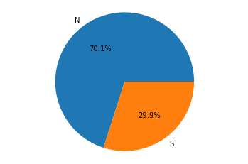

```python
fig1, ax1 = plt.subplots()

ax1.pie(tab['counts'],
        labels=tab['label'],autopct='%1.1f%%',)
ax1.axis('equal')



plt.show()
```

```python
tab1 = pd.crosstab(df2['Departamento Inversion'],df2['Municipio de PostConflico?'])
tab1
```

| Municipio de PostConflico? Departamento Inversion | N | S |
| --- | --- | --- |
| AMAZONAS | 26 | 0 |
| ANTIOQUIA | 24139 | 23747 |
| ARAUCA | 0 | 4841 |
| ATLANTICO | 2451 | 0 |
| BOGOTA D.E. | 4057 | 0 |
| BOLIVAR | 4727 | 3840 |
| BOYACA | 53257 | 1129 |
| CALDAS | 14082 | 1437 |
| CAQUETA | 0 | 7890 |
| CASANARE | 5301 | 4209 |
| CAUCA | 9934 | 21306 |
| CESAR | 2976 | 3656 |
| CHOCO | 295 | 2128 |
| CORDOBA | 11110 | 2965 |
| CUNDINAMARCA | 47390 | 2631 |
| GUAINIA | 45 | 0 |
| GUAJIRA | 673 | 1599 |
| GUAVIARE | 0 | 1633 |
| HUILA | 30380 | 3877 |
| MAGDALENA | 4353 | 1728 |
| META | 5986 | 7086 |
| NARIÑO | 33228 | 11547 |
| NORTE DE SANTANDER | 8812 | 6892 |
| PUTUMAYO | 1445 | 5458 |
| QUINDIO | 3865 | 0 |
| RISARALDA | 6942 | 652 |
| SAN ANDRES | 146 | 0 |
| SANTANDER | 29646 | 5919 |
| SUCRE | 5389 | 1285 |
| TOLIMA | 22589 | 9680 |
| VALLE | 8637 | 8772 |
| VAUPES | 0 | 70 |
| VICHADA | 403 | 205 |

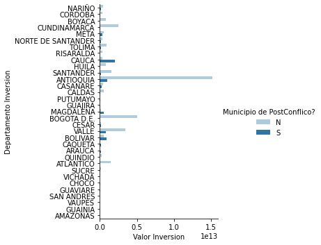

```python
sns.catplot(data = df2,
            kind = "bar",
            estimator = sum,
            x = "Valor Inversion",
            y = "Departamento Inversion",
            hue = "Municipio de PostConflico?",
            palette = 'Paired',
            ci = None)
plt.show()
```